# What Severe Weather Events have caused the Greatest Population Health and Economic Consequences in the U.S.

## Synopsis:

Storms and other severe weather events can cause both public health and economic problems for communities and municipalities. Many severe events can result in fatalities, injuries, and property damage, and preventing such outcomes to the extent possible is a key concern.

By using the U.S. National Oceanic and Atmospheric Administration’s (NOAA) storm database. Can have determined most danagerous adn costly weather events.

Based on our research, “Heat Waves” have the highest Average injury/Fatality rate of all weather related events followed by “Tropical Storms” Based on our research, “Tornadoes, TSTM Winds, Hail” have the highest Average Cost per event of all weather related events, followed by “Heavy RainWeather”

## Data Processing:

### Data

The data for this assignment come in the form of a comma-separated-value file compressed via the bzip2 algorithm to reduce its size. You can download the file from the course web site:

[Storm Data](https://d396qusza40orc.cloudfront.net/repdata%2Fdata%2FStormData.csv.bz2): [47Mb]

There is also some documentation of the database available. Here you will find how some of the variables are constructed/defined.

National Weather Service [Storm Data Documentation](https://d396qusza40orc.cloudfront.net/repdata%2Fpeer2_doc%2Fpd01016005curr.pdf)

National Climatic Data Center Storm Events [FAQ](https://d396qusza40orc.cloudfront.net/repdata%2Fpeer2_doc%2FNCDC%20Storm%20Events-FAQ%20Page.pdf)

The events in the database start in the year 1950 and end in November 2011. In the earlier years of the database there are generally fewer events recorded, most likely due to a lack of good records. More recent years should be considered more complete.

### Loading Data

```r
fileURL <- "https://github.com/aisley/RepData_PeerAssessment2/blob/master/Data/repdata-data-StormData.csv.bz2"

SourceFile <- "repdata-data-StormData.csv.bz2"
fileDir <- "Data"

#Check if Data Dir exists adn create if not
if(!file.exists(fileDir)) {
     dir.create(fileDir)
}

#Get the Data dir to place the files
DataFileDir <- paste(getwd(), fileDir, sep="/")

zipFile <- paste(DataFileDir, SourceFile, sep="/")
if(!file.exists(zipFile))
     {
          download.file(fileURL, destfile=SourceFile)
     } else {
          NOAAStormDataRaw <- read.csv(zipFile, header=TRUE)
     }
```

Lets take a look at a sample of the data that was loaded.

```r
str(NOAAStormDataRaw)
```

```
## 'data.frame':    902297 obs. of  37 variables:
##  $ STATE__   : num  1 1 1 1 1 1 1 1 1 1 ...
##  $ BGN_DATE  : Factor w/ 16335 levels "1/1/1966 0:00:00",..: 6523 6523 4242 11116 2224 2224 2260 383 3980 3980 ...
##  $ BGN_TIME  : Factor w/ 3608 levels "00:00:00 AM",..: 272 287 2705 1683 2584 3186 242 1683 3186 3186 ...
##  $ TIME_ZONE : Factor w/ 22 levels "ADT","AKS","AST",..: 7 7 7 7 7 7 7 7 7 7 ...
##  $ COUNTY    : num  97 3 57 89 43 77 9 123 125 57 ...
##  $ COUNTYNAME: Factor w/ 29601 levels "","5NM E OF MACKINAC BRIDGE TO PRESQUE ISLE LT MI",..: 13513 1873 4598 10592 4372 10094 1973 23873 24418 4598 ...
##  $ STATE     : Factor w/ 72 levels "AK","AL","AM",..: 2 2 2 2 2 2 2 2 2 2 ...
##  $ EVTYPE    : Factor w/ 985 levels "   HIGH SURF ADVISORY",..: 834 834 834 834 834 834 834 834 834 834 ...
##  $ BGN_RANGE : num  0 0 0 0 0 0 0 0 0 0 ...
##  $ BGN_AZI   : Factor w/ 35 levels "","  N"," NW",..: 1 1 1 1 1 1 1 1 1 1 ...
##  $ BGN_LOCATI: Factor w/ 54429 levels "","- 1 N Albion",..: 1 1 1 1 1 1 1 1 1 1 ...
##  $ END_DATE  : Factor w/ 6663 levels "","1/1/1993 0:00:00",..: 1 1 1 1 1 1 1 1 1 1 ...
##  $ END_TIME  : Factor w/ 3647 levels ""," 0900CST",..: 1 1 1 1 1 1 1 1 1 1 ...
##  $ COUNTY_END: num  0 0 0 0 0 0 0 0 0 0 ...
```

[output cut: 23 more lines]

The Storm data set consisted of 902297 rows and 37 columns.

### Data Cleansing

We need to clean up the data set to make it usable. The steps are as follows:

1. Converrt the BGN_DAte to a date format
2. Trim down the data set to only to columns necessary for our analysis.
   - eventType - EVTYPE
   - PersonalInjuries - Number of FATALITIES + INJURIES by event
   - propertyDamage - multiply PROPDMG + CROPDMG by the appropriate multiplier of K, M, B.

The data has several values out side of the range (B, M, K). All other values will be multipled by 1.

```r
NOAAStormDataRaw$BGN_DATE<-as.Date(as.character(NOAAStormDataRaw$BGN_DATE), "%m/%d/%Y")

convertDMGAmt <- function(dmg, multiplier) {
    if (toupper(multiplier) == "K"){
        as.numeric(dmg)*1000
    }
    else if (toupper(multiplier) == "M") {
        as.numeric(dmg)*1000000
    }
    else if (toupper(multiplier) == "B") {
      as.numeric(dmg)*1000000000
    }
    else {
        as.numeric(dmg)
    }
}


propDmg <- apply(NOAAStormDataRaw[, c('PROPDMG', 'PROPDMGEXP')], 1, function(y) convertDMGAmt(y['PROPDMG'], y['PROPDMGEXP']))
cropDmg <- apply(NOAAStormDataRaw[, c('CROPDMG', 'CROPDMGEXP')], 1, function(y) convertDMGAmt(y['CROPDMG'], y['CROPDMGEXP']))

#trim down the data set
NOAAStormData <- data.frame(
     eventType=NOAAStormDataRaw$EVTYPE,
     PersonalInjuries=NOAAStormDataRaw$FATALITIES + NOAAStormDataRaw$INJURIES,
     propertyDamage=propDmg + cropDmg)
```

## Results:

### Across the United States, which types of events (as indicated in the EVTYPE variable) are most harmful with respect to population health?

By taking the mean of each event, we can see by event the mean number of injuries/fatalities that occur.

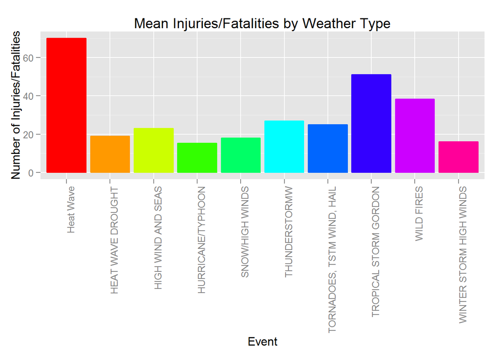

```r
library(plyr)
PersonalInjuries_mean <-ddply(NOAAStormData, .(eventType), summarize, mean_value = mean(PersonalInjuries))

PersonalInjuries_mean_10 <- head(PersonalInjuries_mean[order(PersonalInjuries_mean$mean_value, decreasing=TRUE),], n=10)

#Plot the top 10 values by event type
library(ggplot2)
p <- ggplot(PersonalInjuries_mean_10 , aes(x=eventType, y=mean_value))
p <- p + geom_histogram(stat="identity", binwidth=1000, color=rainbow(10), fill=rainbow(10))
p <- p + xlab("Event")
p <- p + ylab("Number of Injuries/Fatalities")
p <- p + ggtitle("Mean Injuries/Fatalities by Weather Type")
p <- p + theme(axis.text.x = element_text(angle = 90, hjust = 1))
# add a mean line to the hist
p
```

Based on our data, Heat Waves have the highest Average injury/Fatality rate of all weather related events.

### Across the United States, which types of events have the greatest economic consequences?

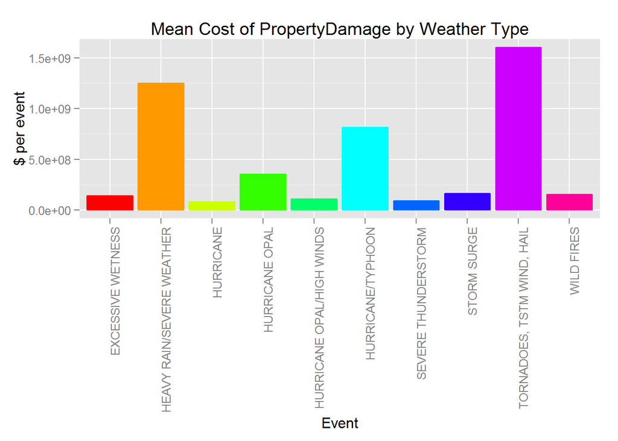

```r
PropertyDamage_mean <-ddply(NOAAStormData, .(eventType), summarize, mean_value = mean(propertyDamage))

PropertyDamage_mean_10 <- head(PropertyDamage_mean[order(PropertyDamage_mean$mean_value, decreasing=TRUE),], n=10)

#Plot the top 10 values by event type

p <- ggplot(PropertyDamage_mean_10 , aes(x=eventType, y=mean_value))
p <- p + geom_histogram(stat="identity", binwidth=1000, color=rainbow(10), fill=rainbow(10))
p <- p + xlab("Event")
p <- p + ylab("$ per event")
p <- p + ggtitle("Mean Cost of PropertyDamage by Weather Type")
p <- p + theme(axis.text.x = element_text(angle = 90, hjust = 1))
# add a mean line to the hist
p
```

Based on our data, Tornadoes, TSTM Winds, Hail have the highest Average Cost per event of all weather related events.